# 2_ReportLIDARModellingResults

L Leston

29/04/2020

Model coefficients for the best *N*-mixture model predicting abundance of Alder Flycatcher *Empidonax alnorum* from LIDAR-based data at the 150-m scale (AIC= 145) (A), and 500-m scale (AIC= 152.18) (B), along with predicted abundances of this species in the Kirby grid from these respective models (C-D).

A

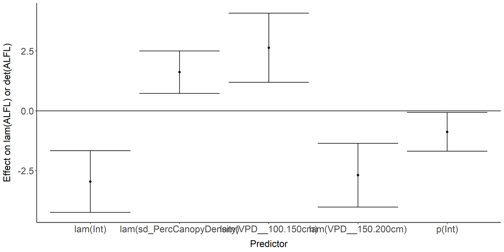

C

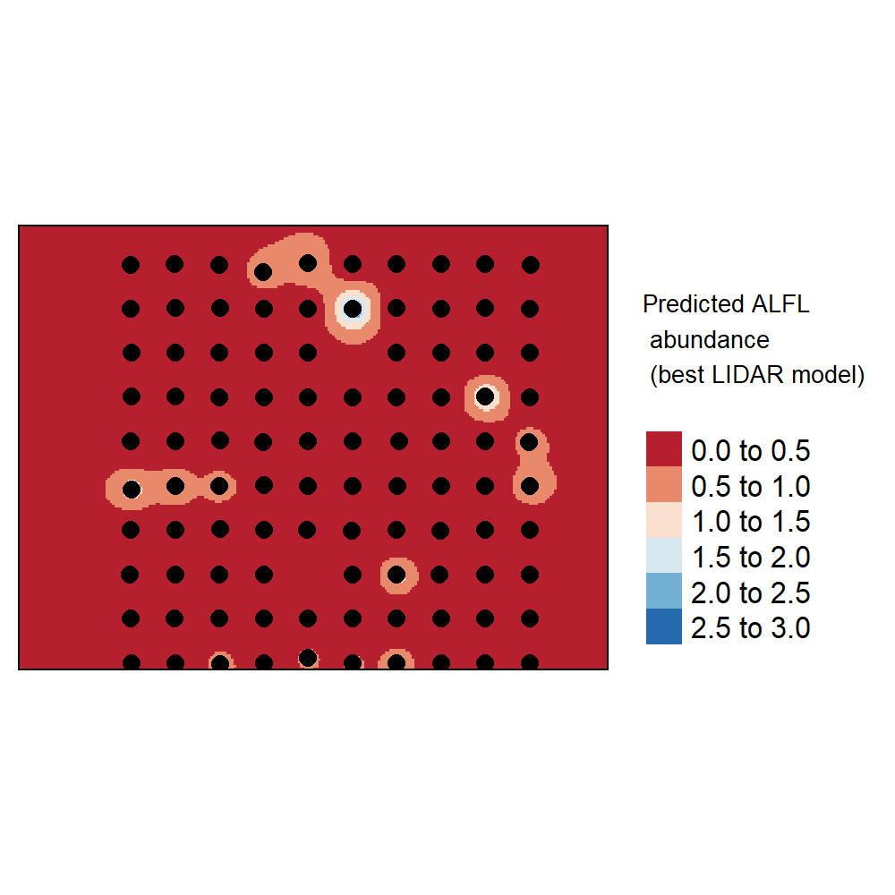

B

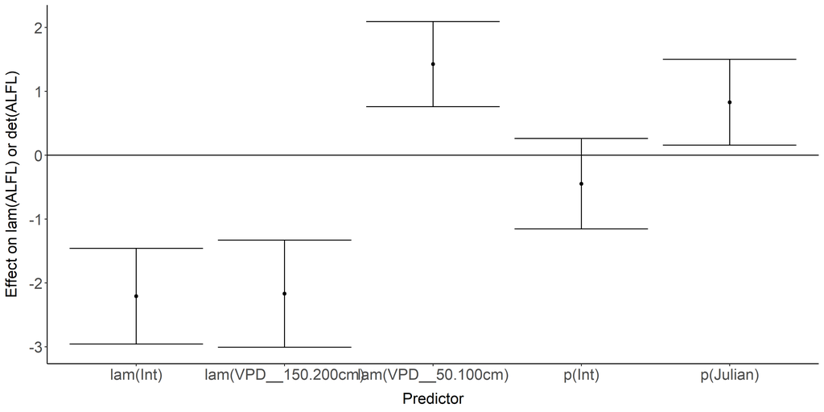

D

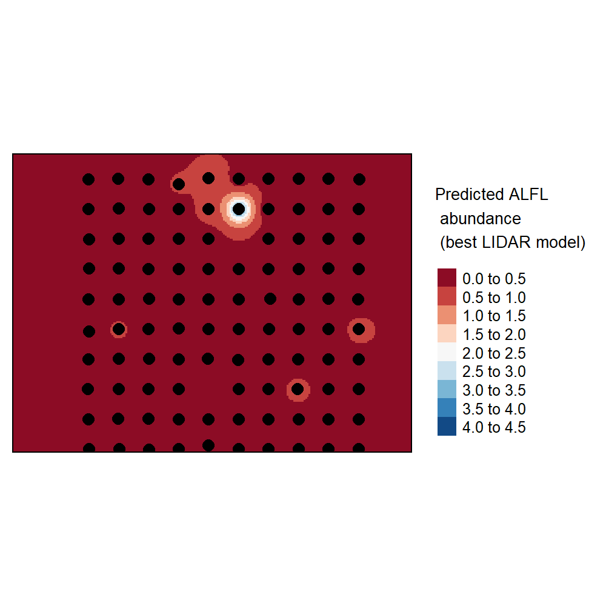

Model coefficients for the best *N*-mixture model predicting abundance of American Robin *Turdus migratorius* from LIDAR-based data at the 150-m scale (AIC= 285.99) (A), and 500-m scale (AIC= 286.04) (B), along with predicted abundances of this species in the Kirby grid from these respective models (C-D).

A

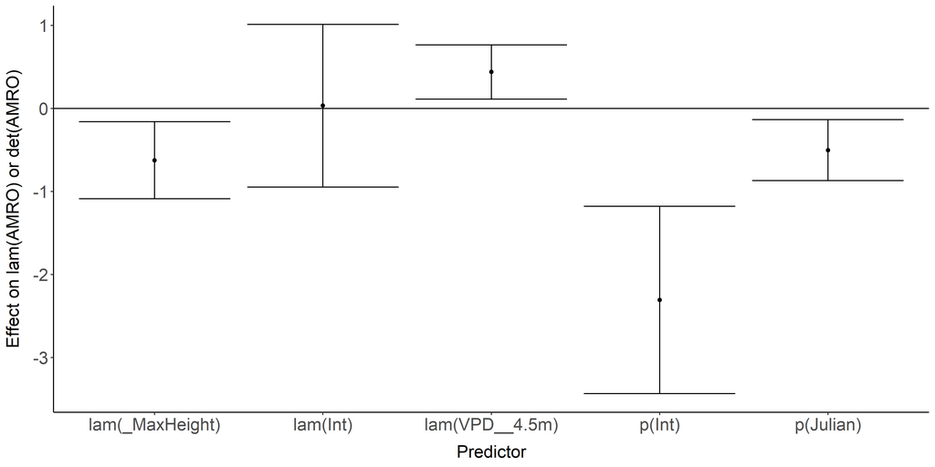

C

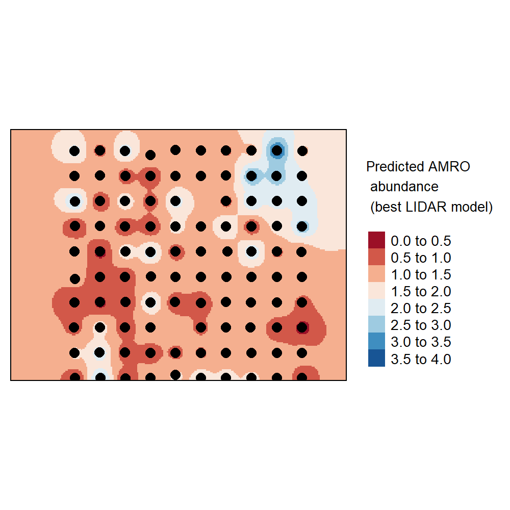

B

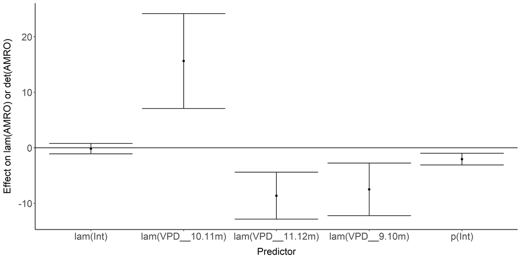

D

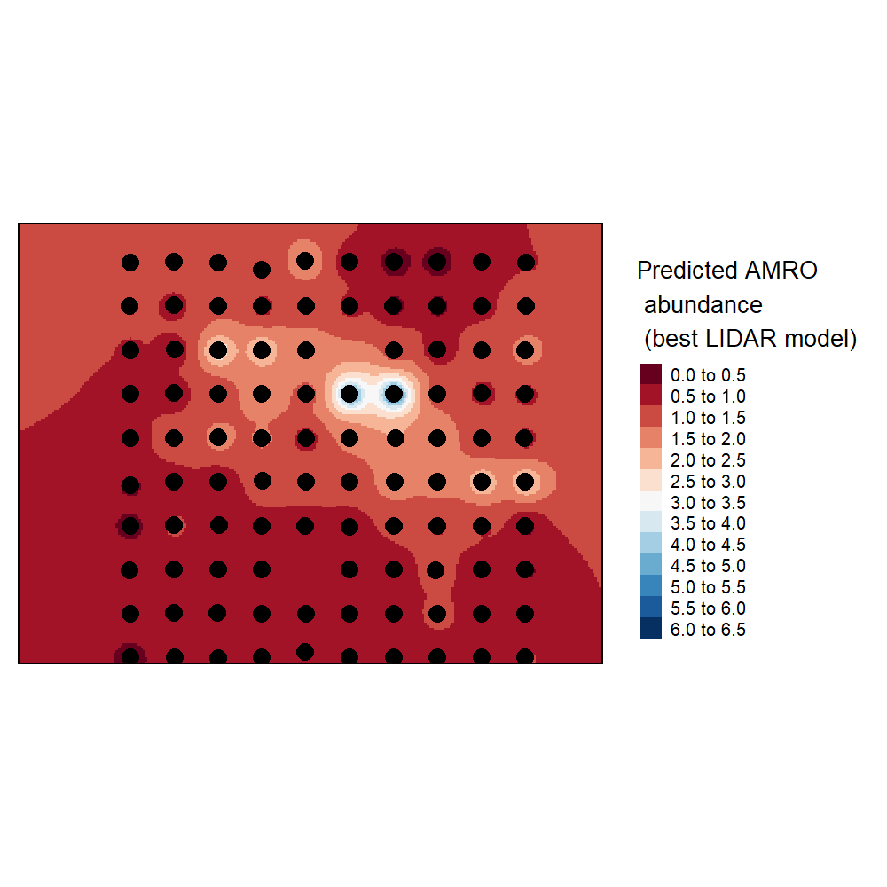

Model coefficients for the best *N*-mixture model predicting abundance of Boreal Chickadee *Poecile hudsonicus* from LIDAR-based data at the 150-m scale (AIC= 127.93) (A), and 500-m scale (AIC= 130.84) (B), along with predicted abundances of this species in the Kirby grid from these respective models (C-D).

A

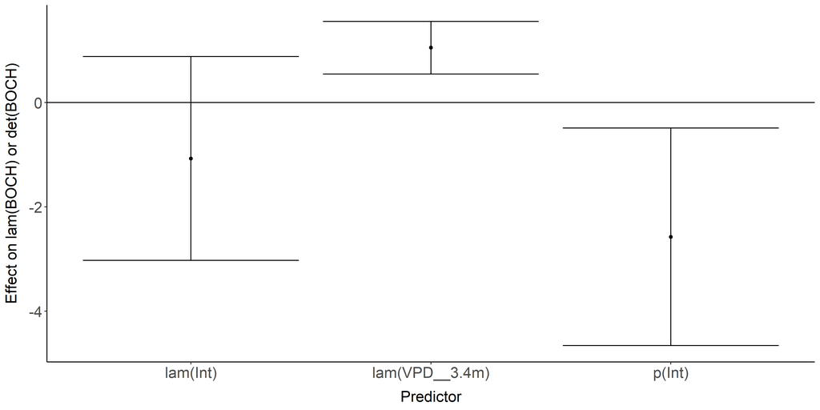

C

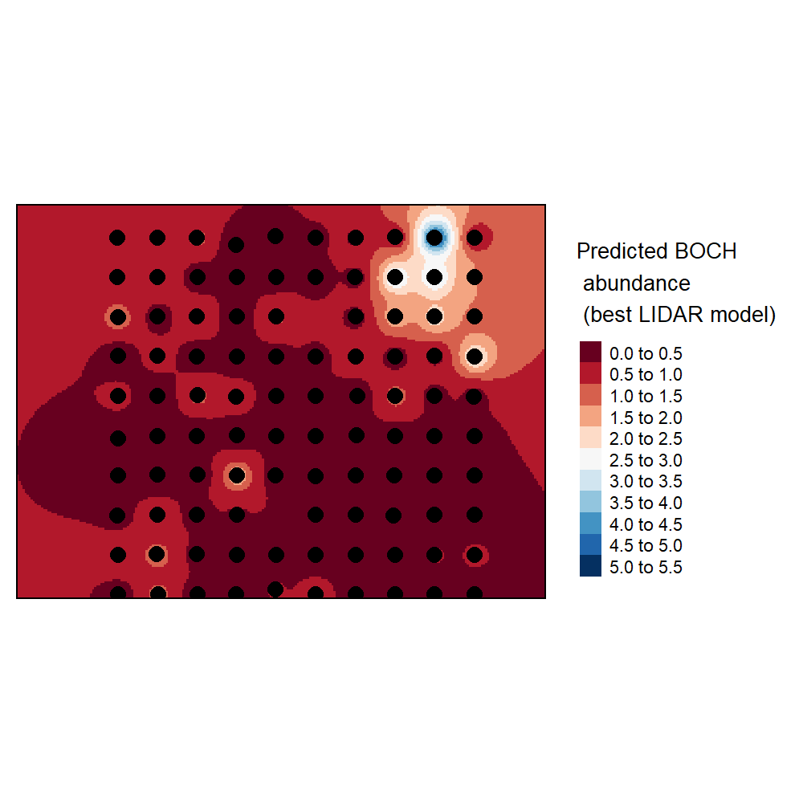

B

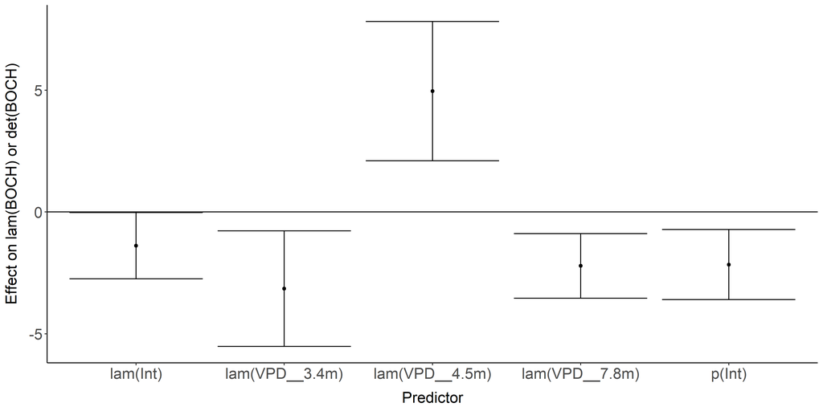

D

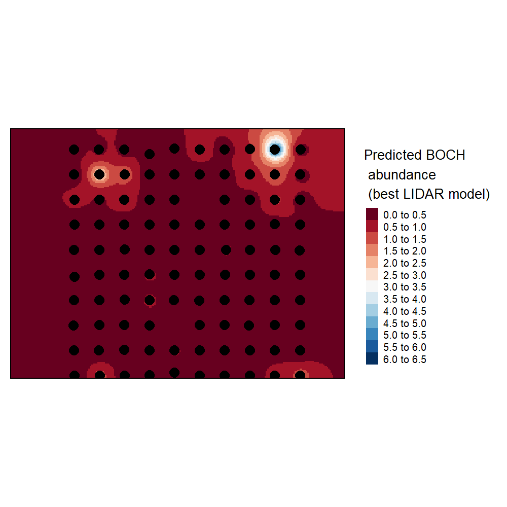

Model coefficients for the best *N*-mixture model predicting abundance of Cedar Waxwing *Bombycilla cedrorum* from LIDAR-based data at the 150-m scale (AIC= 126.29) (A), and 500-m scale (AIC= 123.71) (B), along with predicted abundances of this species in the Kirby grid from these respective models (C-D).

A

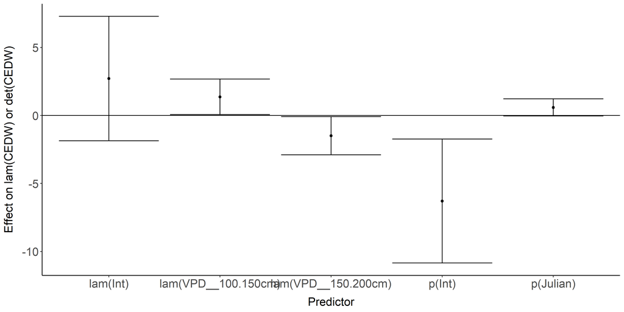

C

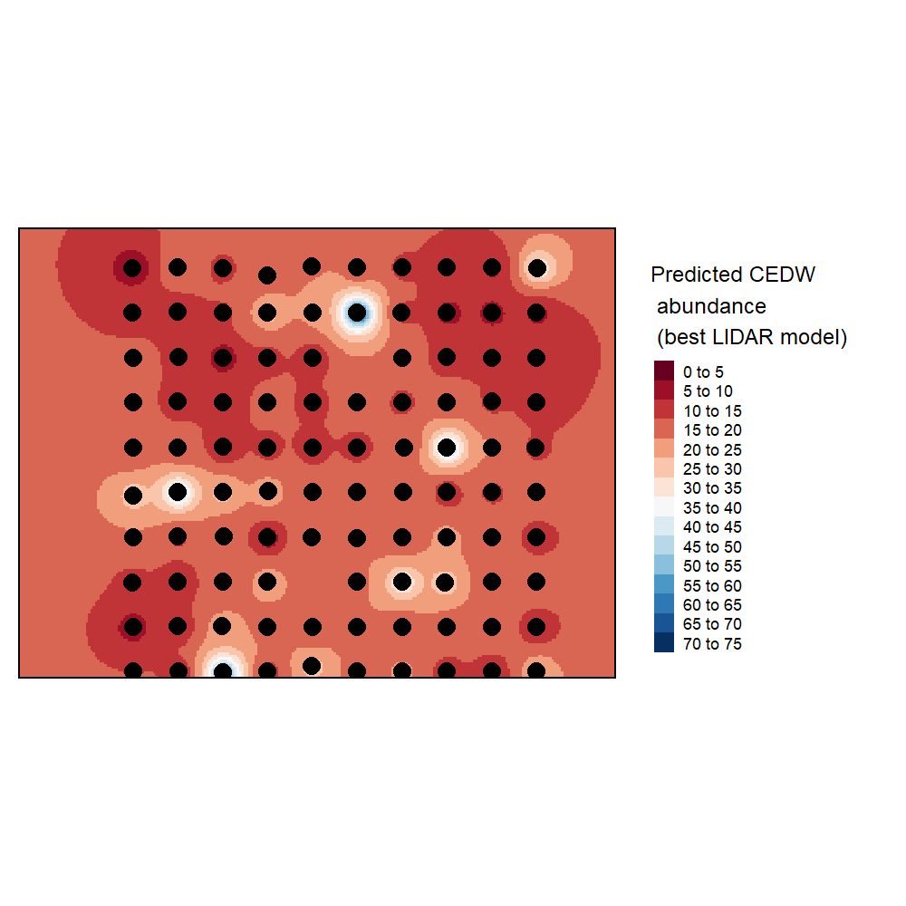

B

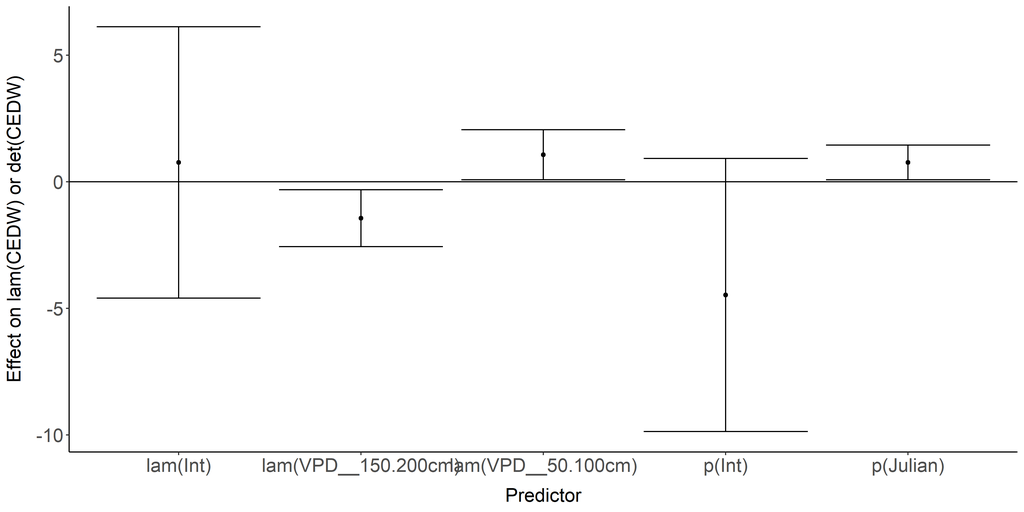

D

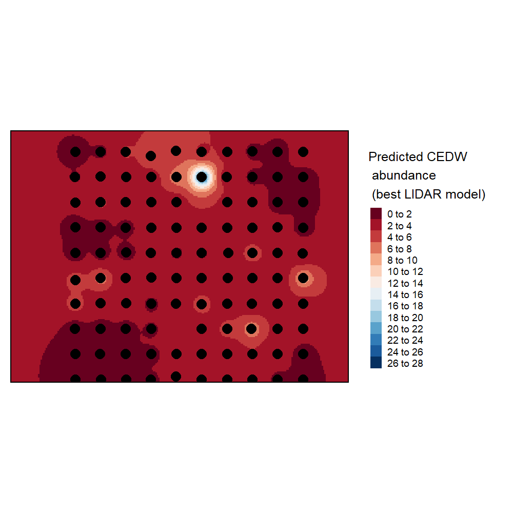

Model coefficients for the best *N*-mixture model predicting abundance of Chipping Sparrow *Spizella passerina* from LIDAR-based data at the 150-m scale (AIC= 550.27) (A), and 500-m scale (AIC= 574.45) (B), along with predicted abundances of this species in the Kirby grid from these respective models (C-D).

A

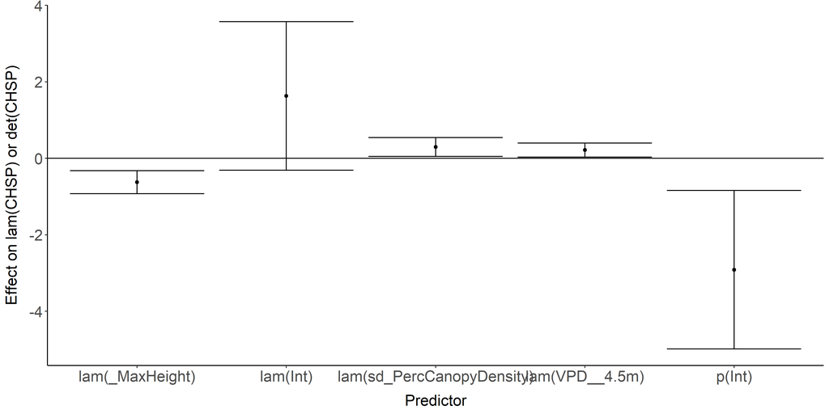

C

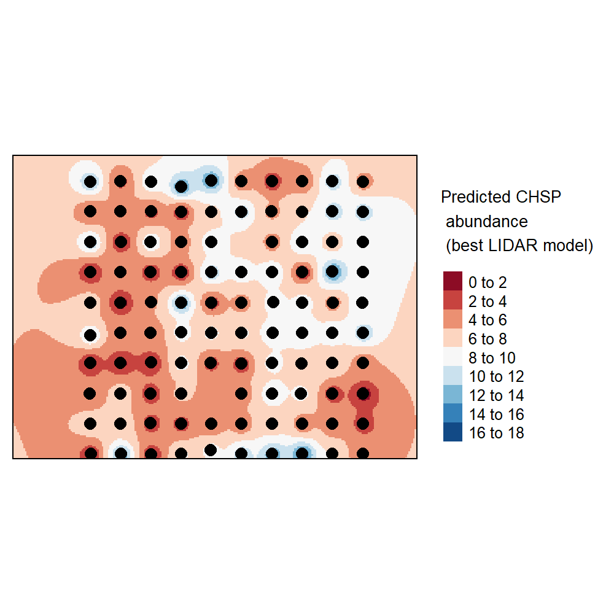

B

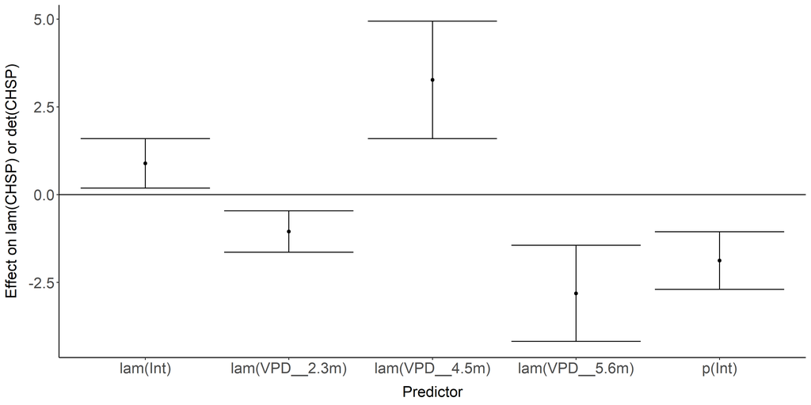

D

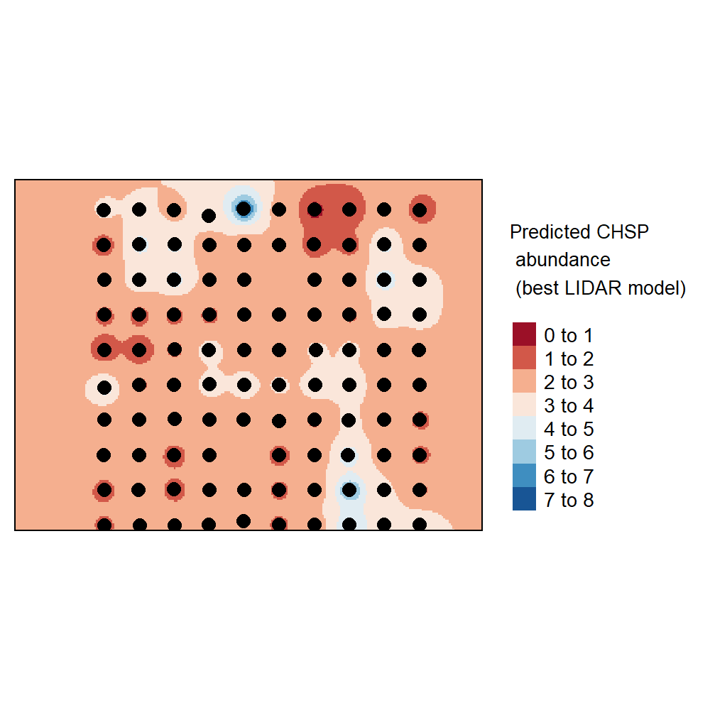

Model coefficients for the best *N*-mixture model predicting abundance of Common Yellowthroat *Geothlypis trichas* from LIDAR-based data at the 150-m scale (AIC= 113.58) (A), and 500-m scale (AIC= 114.43) (B), along with predicted abundances of this species in the Kirby grid from these respective models (C-D).

A

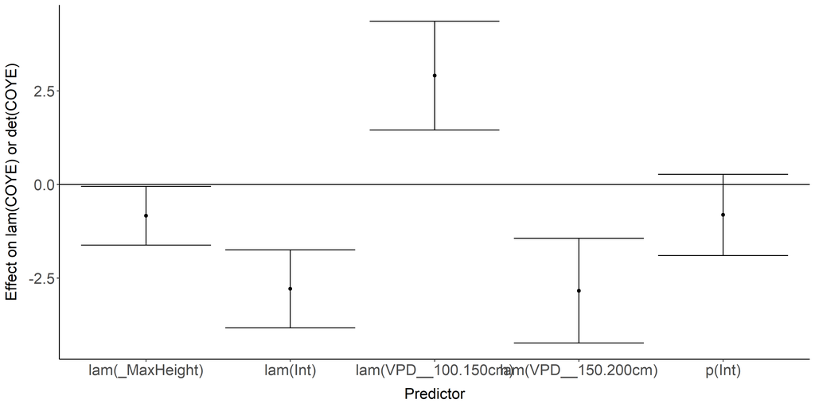

C

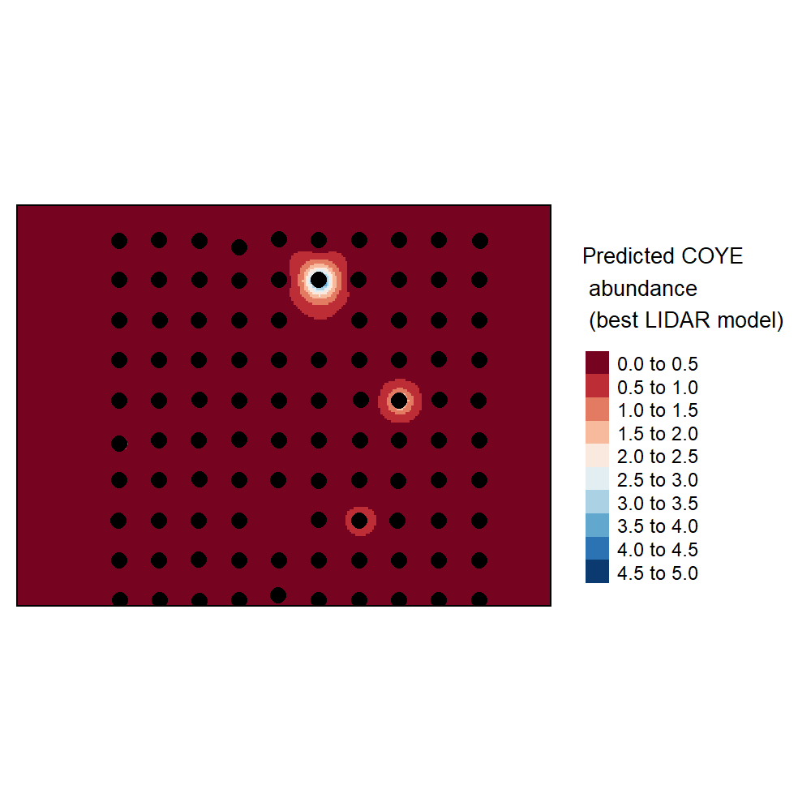

B

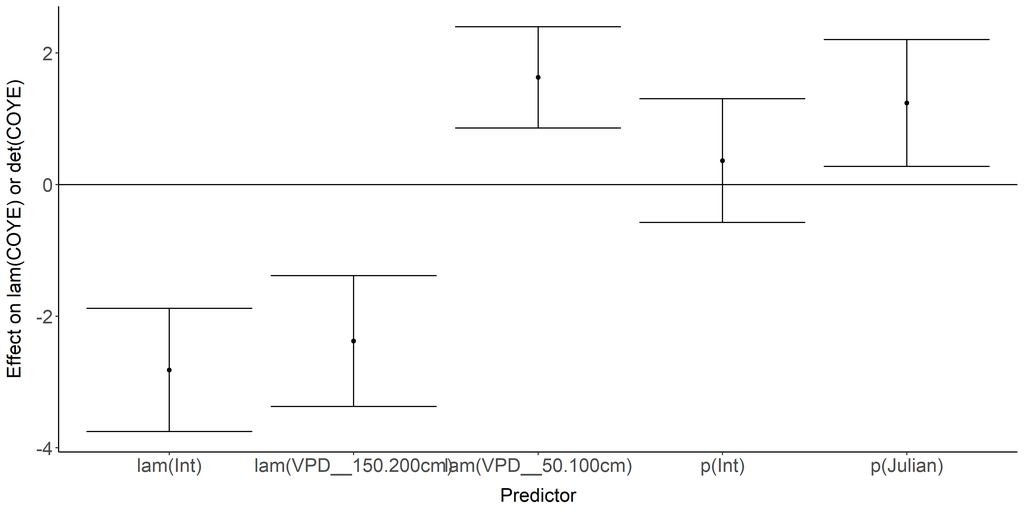

D

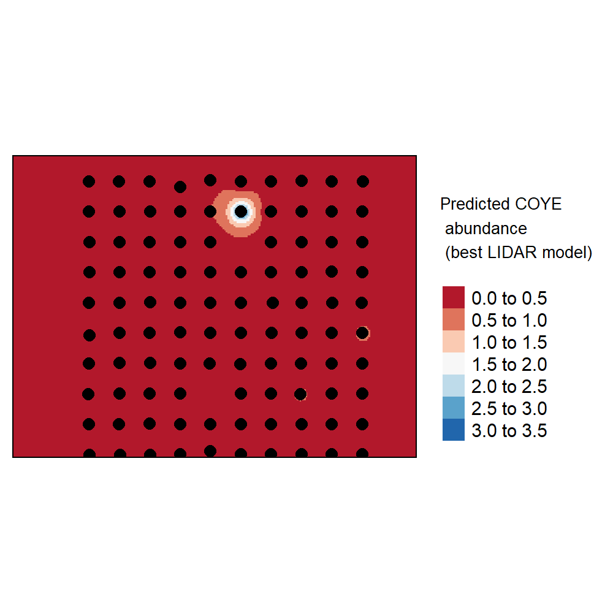

Model coefficients for the best *N*-mixture model predicting abundance of Dark-eyed Junco *Junco hyemalis* from LIDAR-based data at the 150-m scale (AIC= 422.02) (A), and 500-m scale (AIC= 430.56) (B), along with predicted abundances of this species in the Kirby grid from these respective models (C-D).

A

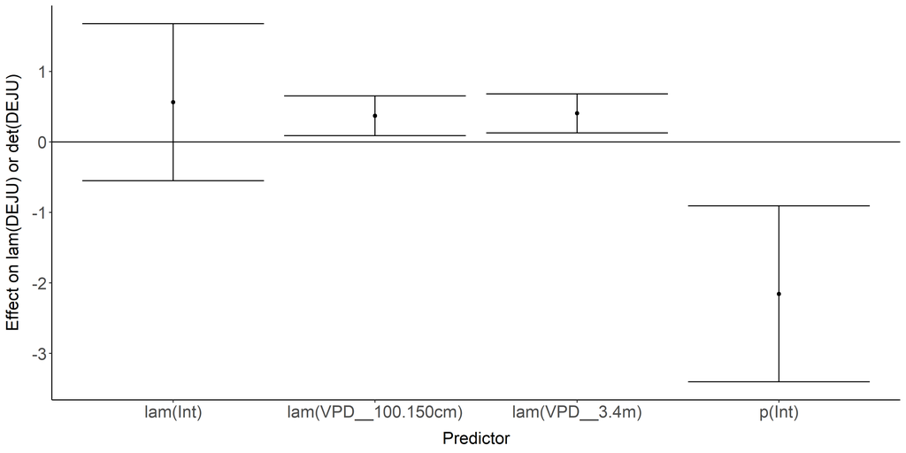

C

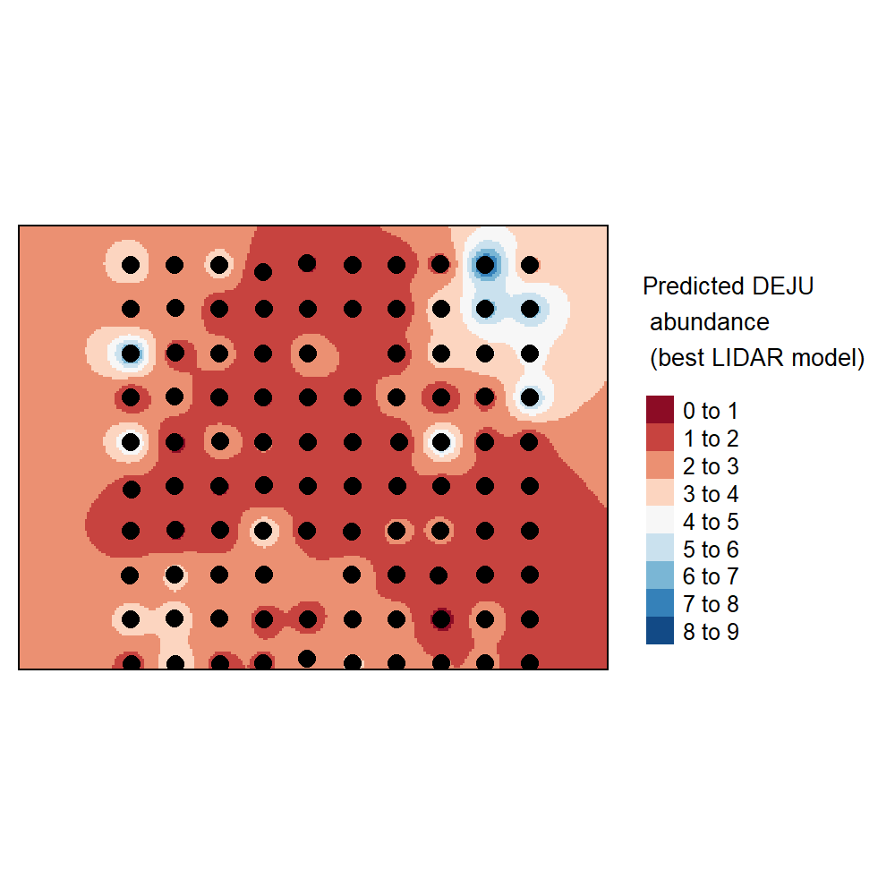

B

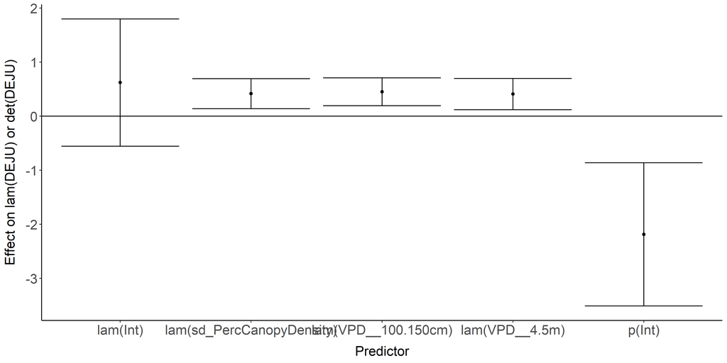

D

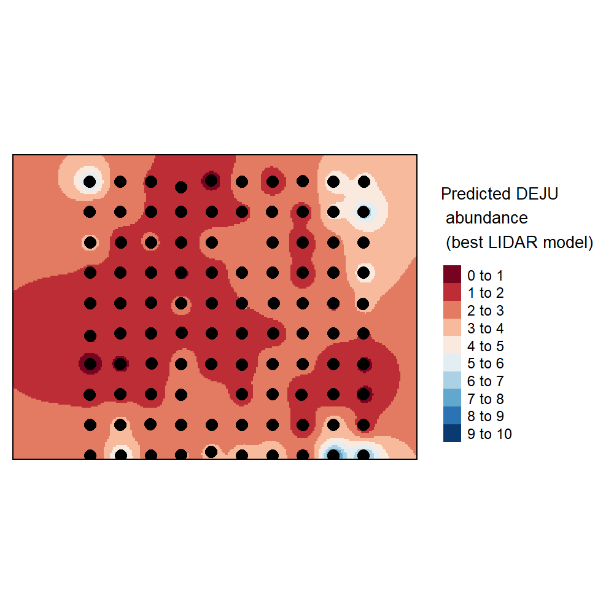

Model coefficients for the best *N*-mixture model predicting abundance of Gray Jay *Perisoreus canadensis* from LIDAR-based data at the 150-m scale (AIC= 465.27) (A), and 500-m scale (AIC= 461.19) (B), along with predicted abundances of this species in the Kirby grid from these respective models (C-D).

A

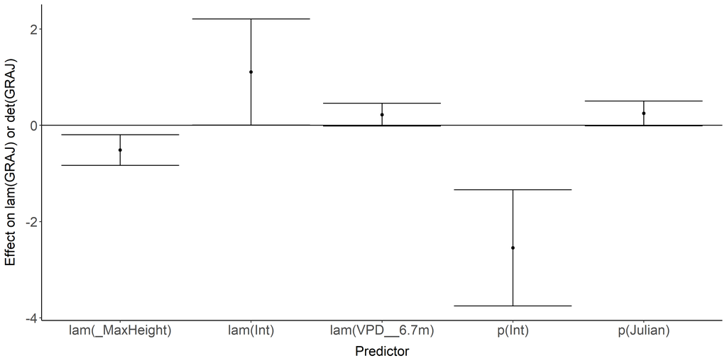

C

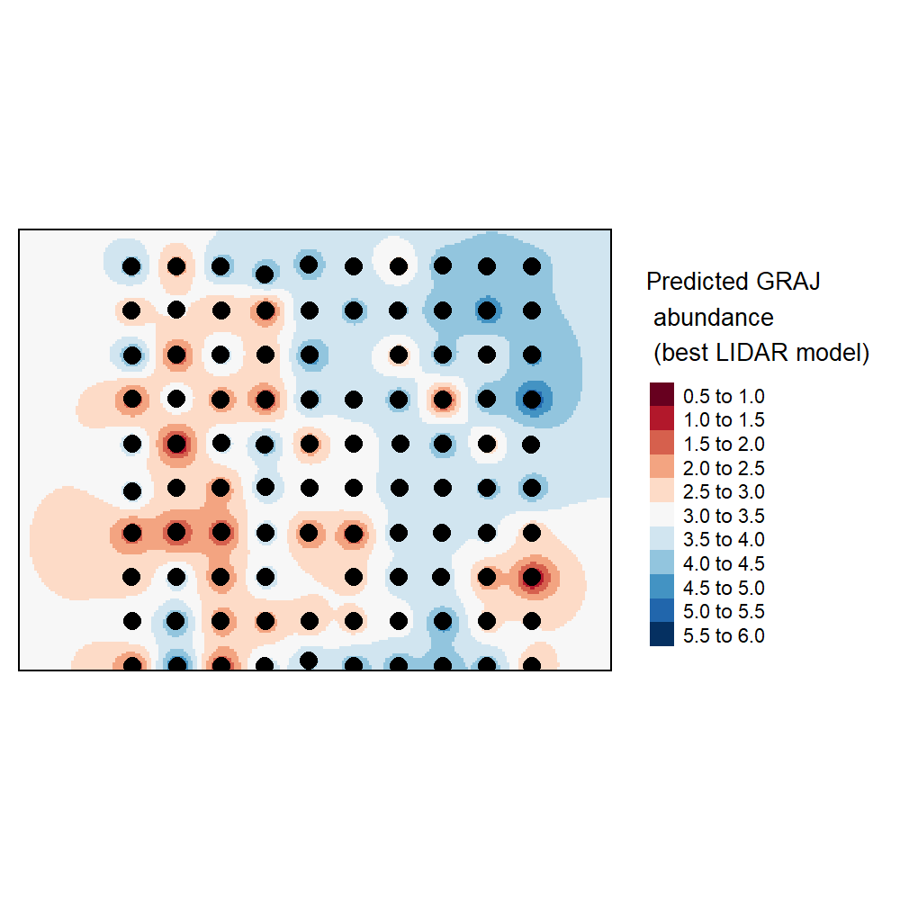

B

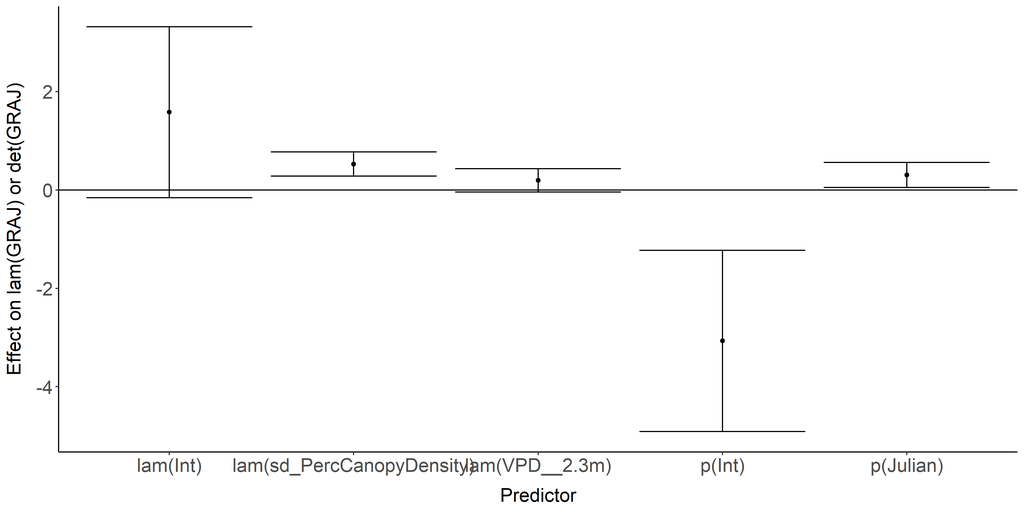

D

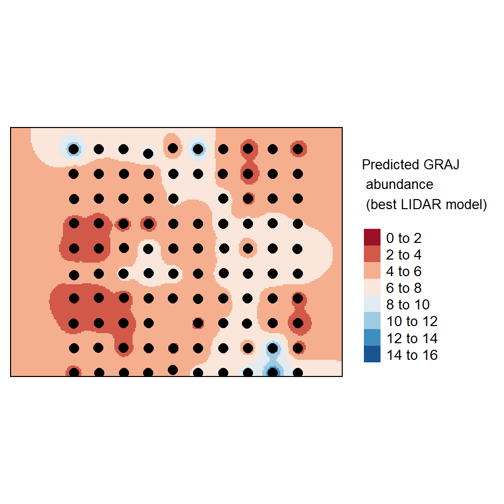

Model coefficients for the best *N*-mixture model predicting abundance of Hermit Thrush *Catharus guttatus* from LIDAR-based data at the 150-m scale (AIC= 679.97) (A), and 500-m scale (AIC= 676.18) (B), along with predicted abundances of this species in the Kirby grid from these respective models (C-D).